# Testes de hipóteses

LendingClub 2007–2014 (dados de desenvolvimento)

# 1 Objetivo e regras

Fase 2 do enunciado (*Hypothesis testing*): para cada hipótese, indicar H0 e HA, justificar o teste e os seus pressupostos, e interpretar o resultado com o **tamanho do efeito** e a sua **incerteza** (intervalo de confiança a 95%). Os dados são observacionais, por isso os resultados mostram **associações, não causas**.

- Só dados de **desenvolvimento** (2007-06 a 2014-12). O teste final (2015) nunca é usado.
- As hipóteses sobre o *default* usam o **treino da classificação** (empréstimos de 36 meses de 2007-06 a 2011-12): é o único conjunto em que o desfecho de cada empréstimo já era conhecido na data de treino simulada.
- Os dados vêm de `notebooks/02b_dados_testes_hipoteses.ipynb`, que os exporta sem alterar nenhum valor.
- Não há transformações aprendidas (imputação, escalamento, etc.): os testes usam os valores limpos tal como estão. Por isso não é preciso um *pipeline* em R.

**Tamanho da amostra e p-valores.** Com dezenas de milhares (ou milhões) de linhas, diferenças muito pequenas dão p-valores próximos de zero. Um p-valor pequeno diz que a diferença provavelmente não é zero, mas não diz se é grande. As conclusões apoiam-se por isso no tamanho do efeito e no seu intervalo de confiança.

# 2 Funções auxiliares

**Correlação rank-biserial** ($r_{rb}$). Tamanho do efeito do teste de Mann-Whitney. Se $X$ é um valor ao acaso do grupo 1 e $Y$ um valor ao acaso do grupo 2,

$$r_{rb} = P(X > Y) - P(X < Y) = 2
\cdot \frac{U}{n_1 n_2} - 1,$$

onde $U$ é a estatística de Mann-Whitney. Vai de $-1$ a $1$; $0$ quer dizer que nenhum grupo tende a ter valores maiores. $U / (n_1 n_2)$ é a AUC: a probabilidade de um valor do grupo 1 ser maior do que um do grupo 2 (os empates contam meio). É igual ao *delta* de Cliff, por isso usam-se os limiares de Romano et al. (2006): $|r| < 0{,}147$ desprezável, $< 0{,}33$ pequeno, $< 0{,}474$ médio, e grande a partir daí.

**Intervalo de confiança por bootstrap.** Reamostra-se cada grupo com reposição, mantendo o tamanho de cada um (bootstrap estratificado), e calcula-se o efeito em cada réplica. O intervalo a 95% são os percentis 2,5% e 97,5% das réplicas. Não exige nenhuma forma para a distribuição do efeito.

**V de Cramér.** Tamanho do efeito do teste do qui-quadrado numa tabela $r \times c$:

$$V = \sqrt{\frac{\chi^2}{n \cdot (\min(r,
c) - 1)}}.$$

Vai de 0 (nenhuma associação) a 1 (associação perfeita) e, ao contrário do $\chi^2$, não cresce com o tamanho da amostra. Numa tabela com 2 colunas, $\min(r, c) - 1 = 1$, e os limiares de Cohen (1988) são 0,1 pequeno, 0,3 médio e 0,5 grande.

```r
# Correlação rank-biserial: x = valores do grupo 1, y = valores do grupo 2
rank_biserial <- function(x, y) {
  n1 <- length(x)
  n2 <- as.numeric(length(y))               # numérico: n1 * n2 passa o limite dos inteiros
  r <- frank(c(x, y), ties.method = "average")   # empates recebem a posição média
  u <- sum(r[seq_len(n1)]) - n1 * (n1 + 1) / 2
  2 * u / (n1 * n2) - 1
}

# Intervalo bootstrap (percentis) do rank-biserial. Cada grupo é reamostrado com reposição
# separadamente, mantendo o seu tamanho (bootstrap estratificado). Feito à mão em vez de
# boot(), que copia a tabela inteira em cada réplica e fica lento com milhões de linhas.
ic_rank_biserial <- function(x, y, reps = B) {
  set.seed(SEMENTE)
  replicas <- replicate(reps, rank_biserial(x[sample.int(length(x), replace = TRUE)],
                                            y[sample.int(length(y), replace = TRUE)]))
  unname(quantile(replicas, c(0.025, 0.975)))
}

# Classificação do tamanho do efeito (Romano et al., 2006)
magnitude_rb <- function(r) {
  cut(abs(r), c(0, 0.147, 0.33, 0.474, 1), include.lowest = TRUE, right = FALSE,
      labels = c("desprezável", "pequeno", "médio", "grande"))
}

# V de Cramér a partir de uma tabela de contingência
cramers_v <- function(tab) {
  chi2 <- suppressWarnings(chisq.test(tab, correct = FALSE)$statistic)
  unname(sqrt(chi2 / (sum(tab) * (min(dim(tab)) - 1))))
}

# Intervalo bootstrap (percentis) do V de Cramér entre duas variáveis categóricas
ic_cramers_v <- function(x, y, reps = B) {
  dados <- data.frame(x = x, y = y)
  estat <- function(d, i) cramers_v(table(d$x[i], d$y[i]))
  set.seed(SEMENTE)
  res <- boot(dados, estat, R = reps)
  boot.ci(res, type = "perc")$percent[4:5]
}

# Classificação do V numa tabela com 2 colunas (Cohen, 1988)
magnitude_v <- function(v) {
  cut(v, c(0, 0.1, 0.3, 0.5, 1), include.lowest = TRUE, right = FALSE,
      labels = c("desprezável", "pequeno", "médio", "grande"))
}

# Formatação para o texto: p-valores abaixo da precisão da máquina aparecem como "< 2.2e-16"
# (o R devolve 0), e montantes sem notação científica
fmt_p <- function(p) {
  if (p < .Machine$double.eps) "< 2.2e-16" else paste("=", format(p, digits = 2))
}
usd <- function(x) format(unname(x), big.mark = " ", scientific = FALSE)

# Os resultados de cada teste juntam-se aqui, para a tabela final
resultados <- list()
```

# 3 Hipótese (a): DTI e *default*

> Enunciado: *“Higher DTI implies higher default risk.”*
- **H0:** o DTI tem a mesma distribuição nos empréstimos *Default* e *Good standing* ($P(X_{Default} > X_{Good}) = 0{,}5$).
- **HA:** o DTI tende a ser **maior** nos *Default* ($P(X_{Default} > X_{Good}) > 0{,}5$). O teste é **unilateral**, porque a hipótese tem uma direção.

```r
cls <- fread("data/processed/hipoteses/default.csv")
# A ordem dos níveis define a direção do teste: "greater" quer dizer Default > Good standing
cls[, target := factor(target, levels = c("Default", "Good standing"))]

cls[, .(n = .N, media = mean(dti), mediana = median(dti),
        q1 = quantile(dti, 0.25), q3 = quantile(dti, 0.75), max = max(dti)), by = target]
```

```
          target     n    media mediana     q1      q3   max
          <fctr> <int>    <num>   <num>  <num>   <num> <num>
1: Good standing 27646 12.97488   12.96 7.7100 18.2800 29.99
2:       Default  3876 13.72358   14.00 8.6275 19.1125 29.96
```

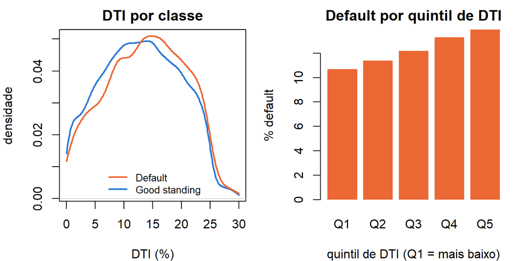

```r
par(mfrow = c(1, 2), mar = c(4, 4, 2, 1))
cores <- c(Default = "#eb6834", "Good standing" = "#2a78d6")   # as cores das figuras da EDA

# Distribuição do DTI em cada classe (densidade)
dens <- lapply(split(cls$dti, cls$target), density, from = 0, to = 30)
plot(dens[["Good standing"]], col = cores[["Good standing"]], lwd = 2, main = "DTI por classe",
     xlab = "DTI (%)", ylab = "densidade", ylim = range(sapply(dens, function(d) d$y)))
lines(dens[["Default"]], col = cores[["Default"]], lwd = 2)
legend("bottom", names(cores), col = cores, lwd = 2, bty = "n", cex = 0.8)

# Taxa de default por quintil de DTI (só descritivo)
quintis <- quantile(cls$dti, 0:5 / 5)
taxa <- cls[, .(taxa = 100 * mean(target == "Default")),
            keyby = .(quintil = cut(dti, quintis, include.lowest = TRUE))]
barplot(taxa$taxa, names.arg = paste0("Q", 1:5), col = cores[["Default"]], border = NA,
        main = "Default por quintil de DTI", xlab = "quintil de DTI (Q1 = mais baixo)",
        ylab = "% default")
```

```r
taxa   # limites de cada quintil e taxa de default
```

```
Key: <quintil>
       quintil     taxa
        <fctr>    <num>
1:     [0,6.6] 10.68038
2:    (6.6,11] 11.40044
3:   (11,15.1] 12.18081
4: (15.1,19.6] 13.29416
5:   (19.6,30] 13.92987
```

**Porquê o teste de Mann-Whitney (Wilcoxon rank-sum).**

- Compara **dois grupos independentes** numa variável **contínua**.
- Usa as **ordens** dos valores e não os valores, por isso não exige normalidade e não é dominado por valores extremos. É o teste não paramétrico indicado no T03 para este caso.
- Alternativa rejeitada: o teste *t* de Welch. Com esta amostra seria válido pelo teorema do limite central, mas compara médias, que são mais sensíveis à forma da distribuição. Mann-Whitney responde diretamente à pergunta “os *Default* tendem a ter DTI maior?”.

**Pressupostos.**

1. **Observações independentes.** Cada linha é um empréstimo diferente. Limitação: não há identificador do mutuário, e estima-se que ~0,5% dos empréstimos sejam de mutuários repetidos (`docs/02_preprocessamento/duplicados.md`). É uma violação pequena.
2. **Variável pelo menos ordinal.** O DTI é contínuo (%, com 2 casas decimais).
3. **Interpretação.** Sem mais pressupostos, o teste compara $P(X > Y)$ com 0,5, que é o que a HA diz. Só seria uma comparação de medianas se as duas distribuições tivessem a mesma forma. As densidades acima têm formas parecidas, por isso a estimativa de Hodges-Lehmann (mediana das diferenças entre pares) pode ler-se como a diferença típica em pontos de DTI.
4. **Empates.** O DTI tem muitos valores repetidos, por isso o p-valor usa a aproximação normal com correção para empates (`exact = FALSE`).

```r
teste_a <- wilcox.test(dti ~ target, data = cls, alternative = "greater", exact = FALSE)
teste_a
```

```
    Wilcoxon rank sum test with continuity correction

data:  dti by target
W = 57067259, p-value = 2.405e-11
alternative hypothesis: true location shift is greater than 0
```

```r
# Diferença de Hodges-Lehmann com intervalo bilateral a 95% (a incerteza nos dois sentidos)
hl_a <- wilcox.test(dti ~ target, data = cls, conf.int = TRUE, exact = FALSE)

x_def <- cls[target == "Default", dti]
x_good <- cls[target == "Good standing", dti]
rb_a <- rank_biserial(x_def, x_good)
ic_a <- ic_rank_biserial(x_def, x_good)

data.frame(
  medida = c("rank-biserial", "AUC = P(X_Default > X_Good)", "Hodges-Lehmann (pontos de DTI)"),
  estimativa = round(c(rb_a, (rb_a + 1) / 2, hl_a$estimate), 3),
  ic95_inf = round(c(ic_a[1], (ic_a[1] + 1) / 2, hl_a$conf.int[1]), 3),
  ic95_sup = round(c(ic_a[2], (ic_a[2] + 1) / 2, hl_a$conf.int[2]), 3)
)
```

```
                          medida estimativa ic95_inf ic95_sup
1                  rank-biserial      0.065    0.045    0.084
2    AUC = P(X_Default > X_Good)      0.533    0.523    0.542
3 Hodges-Lehmann (pontos de DTI)      0.810    0.570    1.060
```

```r
resultados$a <- data.frame(
  hipotese = "(a) DTI maior nos Default",
  dados = "treino da classificação (2007-06 a 2011-12)",
  n = sprintf("%d Default / %d Good", length(x_def), length(x_good)),
  teste = "Mann-Whitney unilateral",
  p = teste_a$p.value,
  efeito = "rank-biserial",
  estimativa = rb_a, ic95_inf = ic_a[1], ic95_sup = ic_a[2],
  magnitude = as.character(magnitude_rb(rb_a))
)
```

**Interpretação.**

- **Rejeita-se H0** ($p$ = 2.4e-11): nos empréstimos em *Default*, o DTI tende a ser maior.
- **Mas o efeito é desprezável**: $r_{rb} =$ 0.065 (IC 95% 0.045 a 0.084). Escolhendo ao acaso um empréstimo em *Default* e um *Good standing*, o primeiro tem o DTI maior em 53.3% dos casos, pouco acima dos 50% que se esperariam sem nenhuma relação. A diferença típica é de 0.81 pontos de DTI (IC 95% 0.57 a 1.06).
- O gráfico da direita mostra a mesma relação: a taxa de *default* sobe de forma monótona com o DTI, de 10.7% no quintil mais baixo para 13.9% no mais alto.
- **O que significa para os modelos:** o DTI tem informação sobre o risco, mas sozinho separa mal as classes. É de esperar que só seja útil em conjunto com outras variáveis (FICO, taxa de juro, *grade*).
- **Nota sobre os dados:** o DTI máximo é 29.99%. Não há nenhum empréstimo com DTI de 30% ou mais, o que indica um limite da política de crédito nestes anos: os requerentes com DTI mais alto foram rejeitados e não estão na amostra. A relação observada é a que existe **entre os aprovados**, e pode ser mais fraca do que na população de requerentes (*selection bias*).
- **Associação, não causalidade:** um DTI mais alto está associado a mais *default*, mas os dados não mostram que o DTI cause o *default*. Ambos podem depender de outros fatores, como o rendimento ou a situação profissional.

# 4 Hipótese (b): `purpose` e *default*

> Enunciado: *“Loan purpose affects default risk.”*
- **H0:** o `purpose` e o desfecho são independentes (a taxa de *default* é a mesma em todos os *purposes*).
- **HA:** não são independentes (a taxa de *default* difere em pelo menos um *purpose*). Não há direção, porque o `purpose` é uma variável nominal (as categorias não têm ordem).

```r
tab_b <- table(cls$purpose, cls$target)
taxa_global <- mean(cls$target == "Default")

# Taxa de default de cada purpose, com intervalo de confiança a 95% (Wilson)
por_purpose <- data.table(purpose = rownames(tab_b), n = rowSums(tab_b), default = tab_b[, "Default"])
por_purpose[, taxa := 100 * default / n]
por_purpose[, c("ic95_inf", "ic95_sup") := {
  ic <- mapply(function(x, n) prop.test(x, n)$conf.int, default, n)
  list(100 * ic[1, ], 100 * ic[2, ])
}]
setorder(por_purpose, -taxa)
por_purpose[, lapply(.SD, function(v) if (is.numeric(v)) round(v, 1) else v)]
```

```
               purpose     n default  taxa ic95_inf ic95_sup
                <char> <num>   <num> <num>    <num>    <num>
 1:     small_business  1386     334  24.1     21.9     26.5
 2:        educational   405      81  20.0     16.3     24.3
 3:   renewable_energy    79      14  17.7     10.4     28.3
 4:             moving   523      86  16.4     13.4     20.0
 5:            medical   578      90  15.6     12.8     18.8
 6:              other  3522     520  14.8     13.6     16.0
 7:           vacation   337      42  12.5      9.2     16.6
 8: debt_consolidation 14104    1715  12.2     11.6     12.7
 9:              house   298      36  12.1      8.7     16.5
10:   home_improvement  2257     265  11.7     10.5     13.2
11:                car  1040      93   8.9      7.3     10.9
12:            wedding   775      69   8.9      7.0     11.2
13:        credit_card  4392     378   8.6      7.8      9.5
14:     major_purchase  1826     153   8.4      7.2      9.8
```

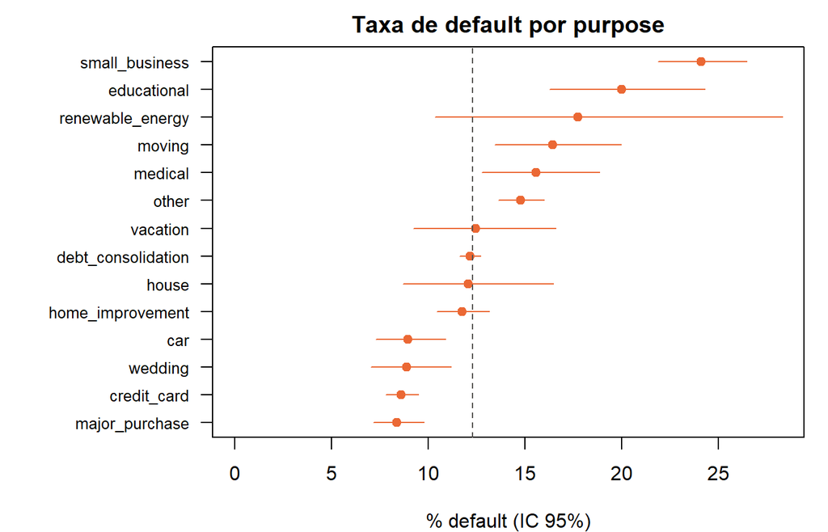

```r
par(mar = c(4, 9, 2, 1))
pos <- rev(seq_len(nrow(por_purpose)))   # o purpose com a taxa mais alta fica em cima
plot(por_purpose$taxa, pos, xlim = range(0, por_purpose$ic95_sup), pch = 19, col = "#eb6834",
     yaxt = "n", xlab = "% default (IC 95%)", ylab = "", main = "Taxa de default por purpose")
segments(por_purpose$ic95_inf, pos, por_purpose$ic95_sup, pos, col = "#eb6834")
axis(2, at = pos, labels = por_purpose$purpose, las = 1, cex.axis = 0.8)
abline(v = 100 * taxa_global, lty = 2, col = "#52514e")   # taxa de todo o treino
```

**Porquê o teste do qui-quadrado de independência.**

- Relaciona **duas variáveis categóricas** (`purpose` com 14 categorias e o desfecho com 2).
- Compara as contagens observadas em cada célula da tabela com as que se esperariam se as duas variáveis fossem independentes: $E_{ij} = \frac{\text{total da linha } i \times \text{total da coluna } j}{n}$. A estatística $\chi^2 = \sum (O - E)^2 / E$ é grande quando as contagens se afastam muito das esperadas.
- Alternativas rejeitadas: o teste exato de Fisher só é necessário com contagens esperadas pequenas (e é muito pesado numa tabela 14 × 2 com 31 mil linhas); uma regressão logística daria a mesma informação com mais pressupostos.

**Pressupostos.**

1. **Observações independentes**, cada uma numa só célula. Cada linha é um empréstimo diferente (com a mesma ressalva dos ~0,5% de mutuários repetidos).
2. **Contagens esperadas de pelo menos 5 em todas as células.** Verifica-se abaixo: a menor é 9.7 (*renewable_energy*), por isso não é preciso juntar categorias.
3. A correção de continuidade de Yates só se aplica a tabelas 2 × 2, por isso não é usada.

```r
teste_b <- chisq.test(tab_b)
teste_b
```

```
    Pearson's Chi-squared test

data:  tab_b
X-squared = 338.9, df = 13, p-value < 2.2e-16
```

```r
cat("Menor contagem esperada:", round(min(teste_b$expected), 1), "\n")
```

```
Menor contagem esperada: 9.7
```

```r
v_b <- cramers_v(tab_b)
ic_b <- ic_cramers_v(cls$purpose, cls$target)
data.frame(medida = "V de Cramér", estimativa = round(v_b, 3),
           ic95_inf = round(ic_b[1], 3), ic95_sup = round(ic_b[2], 3))
```

```
       medida estimativa ic95_inf ic95_sup
1 V de Cramér      0.104    0.093    0.118
```

**Que *purposes* se afastam da taxa global?** O $\chi^2$ só diz que há diferenças, não onde estão. Para isso usam-se os **resíduos padronizados ajustados** da coluna *Default*: $(O - E) / \sqrt{E (1 - p_{linha})(1 - p_{coluna})}$, que seguem aproximadamente uma normal padrão se H0 for verdade. Positivos querem dizer mais *default* do que o esperado. Como se olha para 14 *purposes* ao mesmo tempo, o valor crítico tem a correção de Bonferroni: $|z| > z_{1 - 0{,}05 / (2 \times 14)}$.

```r
z_critico <- qnorm(1 - ALFA / (2 * nrow(tab_b)))
residuos <- data.table(purpose = rownames(tab_b), residuo = teste_b$stdres[, "Default"])
residuos <- merge(por_purpose[, .(purpose, n, taxa)], residuos, by = "purpose")
residuos[, diferente := ifelse(abs(residuo) > z_critico,
                               ifelse(residuo > 0, "mais default", "menos default"), "-")]
setorder(residuos, -residuo)
cat("Valor crítico (Bonferroni):", round(z_critico, 2), "\n")
```

```
Valor crítico (Bonferroni): 2.91
```

```r
residuos[, .(purpose, n, taxa = round(taxa, 1), residuo = round(residuo, 2), diferente)]
```

```
               purpose     n  taxa residuo     diferente
                <char> <num> <num>   <num>        <char>
 1:     small_business  1386  24.1   13.68  mais default
 2:        educational   405  20.0    4.75  mais default
 3:              other  3522  14.8    4.73  mais default
 4:             moving   523  16.4    2.91             -
 5:            medical   578  15.6    2.42             -
 6:   renewable_energy    79  17.7    1.47             -
 7:           vacation   337  12.5    0.09             -
 8:              house   298  12.1   -0.11             -
 9: debt_consolidation 14104  12.2   -0.66             -
10:   home_improvement  2257  11.7   -0.83             -
11:            wedding   775   8.9   -2.91             -
12:                car  1040   8.9   -3.35 menos default
13:     major_purchase  1826   8.4   -5.25 menos default
14:        credit_card  4392   8.6   -8.03 menos default
```

```r
resultados$b <- data.frame(
  hipotese = "(b) purpose associado ao default",
  dados = "treino da classificação (2007-06 a 2011-12)",
  n = sprintf("%d empréstimos, 14 purposes", sum(tab_b)),
  teste = "Qui-quadrado de independência",
  p = teste_b$p.value,
  efeito = "V de Cramér",
  estimativa = v_b, ic95_inf = ic_b[1], ic95_sup = ic_b[2],
  magnitude = as.character(magnitude_v(v_b))
)
```

**Interpretação.**

- **Rejeita-se H0** ($\chi^2 =$ 338.9, 13 graus de liberdade, $p$ < 2.2e-16): a taxa de *default* não é a mesma em todos os *purposes*.
- **O efeito é pequeno**: $V =$ 0.104 (IC 95% 0.093 a 0.118).
- Mesmo assim, as diferenças entre categorias são grandes: a taxa vai de 8.4% (major_purchase) a 24.1% (small_business), para uma taxa global de 12.3%. O V é pequeno porque a maior parte dos empréstimos está em *purposes* perto da média (*debt_consolidation* sozinho tem 45% do treino), e o V mede a associação no conjunto de todos os empréstimos.
- Com a correção de Bonferroni, têm **mais *default*** do que o esperado: small_business, educational, other; e **menos *default***: car, major_purchase, credit_card. Os restantes não se distinguem da taxa global (*moving* e *wedding* ficam mesmo no limite). Categorias pequenas como *renewable_energy* (79 empréstimos) têm intervalos largos e nada se pode concluir sobre elas.
- **O que significa para os modelos:** o `purpose` é uma variável útil, sobretudo para separar os casos de *small_business* (risco alto) dos de *credit_card* e *major_purchase* (risco baixo). As categorias raras devem ser agrupadas, como já faz o *pipeline* (`OneHotEncoder` com frequência mínima).
- **Associação, não causalidade:** o *purpose* é escolhido pelo mutuário, e quem escolhe cada um pode ter um perfil diferente (rendimento, FICO, estabilidade do rendimento). Por exemplo, o risco de *small_business* pode vir da incerteza do rendimento de um negócio e não do *purpose* em si. Os dados não permitem separar estas explicações.

# 5 Hipótese (c): aceites vs rejeitados

> Enunciado: *“Requested amount differs between accepted and rejected applications”* e *“Lower risk score implies higher rejection”*.

Junta-se o ficheiro de aceites ao de rejeitados, ambos do desenvolvimento. As colunas foram postas com o mesmo nome e a mesma unidade em `02b_dados_testes_hipoteses.ipynb`:

| Coluna | Aceites | Rejeitados |
| --- | --- | --- |
| `amount` (USD) | `loan_amnt` | `amount_requested` |
| `risk_score` | ponto médio de `fico_range_low` e `fico_range_high` | `risk_score` |
| `date` | `issue_d` (mês de financiamento) | `application_date` (dia do pedido) |

**Limitações da comparação:**

- O `loan_amnt` dos aceites pode refletir reduções feitas pela LendingClub (dicionário de dados), por isso não é exatamente o montante pedido.
- A data dos aceites é o mês de financiamento e não a do pedido; os cortes de calendário são por isso aproximados nos aceites.
- Não há identificador do requerente: a mesma pessoa pode ter vários pedidos rejeitados (só os pedidos exatamente iguais foram retirados na limpeza) ou ter sido rejeitada e aceite mais tarde. Os dois grupos não são por isso totalmente independentes.

```r
grupos <- fread("data/processed/hipoteses/aceites_rejeitados.csv")
grupos[, .N, by = group]
```

```
       group       N
      <char>   <int>
1:    aceite  466124
2: rejeitado 3424228
```

## 5.1 (c1) Montante pedido

- **H0:** o montante pedido tem a mesma distribuição nos aceites e nos rejeitados.
- **HA:** as distribuições diferem. O teste é **bilateral**, porque o enunciado não indica a direção (*“differs”*).
- Usa-se todo o desenvolvimento (2007-06 a 2014-12): o montante não depende da escala do *risk score*.

```r
montante <- grupos[!is.na(amount),
                   .(group = factor(group, levels = c("aceite", "rejeitado")), amount)]
montante[, .(n = .N, q1 = quantile(amount, 0.25), mediana = median(amount), media = mean(amount),
             q3 = quantile(amount, 0.75), p99 = quantile(amount, 0.99), max = max(amount),
             acima_35k = sprintf("%.2f%%", 100 * mean(amount > 35000))), by = group]
```

```
       group       n    q1 mediana    media    q3   p99     max acima_35k
      <fctr>   <int> <num>   <num>    <num> <num> <num>   <num>    <char>
1:    aceite  466124  8000   12000 14315.74 20000 35000   35000     0.00%
2: rejeitado 3424226  4000   10000 12734.75 20000 35000 1400000     0.47%
```

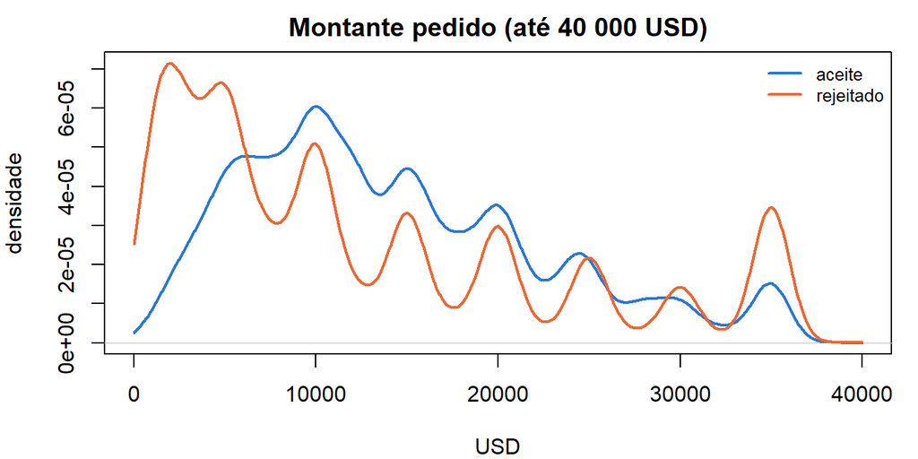

```r
cores_g <- c(aceite = "#2a78d6", rejeitado = "#eb6834")
par(mar = c(4, 4, 2, 1))
# Só até 40 000 USD, para se ver a forma (acima disso só há uma pequena parte dos rejeitados)
ate_40k <- montante[amount <= 40000]
dens_m <- lapply(split(ate_40k$amount, ate_40k$group), density, from = 0, to = 40000, bw = 1000)
plot(dens_m$aceite, col = cores_g[["aceite"]], lwd = 2, main = "Montante pedido (até 40 000 USD)",
     xlab = "USD", ylab = "densidade", ylim = range(sapply(dens_m, function(d) d$y)))
lines(dens_m$rejeitado, col = cores_g[["rejeitado"]], lwd = 2)
legend("topright", names(cores_g), col = cores_g, lwd = 2, bty = "n", cex = 0.8)
```

**Porquê o teste de Mann-Whitney.** São dois grupos independentes e uma variável contínua muito assimétrica, com valores extremos nos rejeitados (até 1,4 milhões de USD). Um teste baseado nas ordens não é afetado por esses extremos, ao contrário de um teste de médias. **Pressupostos:** os mesmos da hipótese (a), com a ressalva da independência acima. Há muitos empates (montantes redondos), tratados pela aproximação normal com correção.

**Bootstrap com milhões de linhas.** Cada réplica demora cerca de 0,5 s, por isso usam-se 500 réplicas em vez de 2000. Chega: com estes tamanhos o intervalo é muito estreito e a sua 3.ª casa decimal não muda com mais réplicas.

```r
teste_c1 <- wilcox.test(amount ~ group, data = montante, exact = FALSE)
teste_c1
```

```
    Wilcoxon rank sum test with continuity correction

data:  amount by group
W = 9.5488e+11, p-value < 2.2e-16
alternative hypothesis: true location shift is not equal to 0
```

```r
m_aceite <- montante[group == "aceite", amount]
m_rejeitado <- montante[group == "rejeitado", amount]
rb_c1 <- rank_biserial(m_aceite, m_rejeitado)
ic_c1 <- ic_rank_biserial(m_aceite, m_rejeitado, reps = B_GRANDE)
data.frame(medida = c("rank-biserial (aceite vs rejeitado)", "AUC = P(X_aceite > X_rejeitado)"),
           estimativa = round(c(rb_c1, (rb_c1 + 1) / 2), 3),
           ic95_inf = round(c(ic_c1[1], (ic_c1[1] + 1) / 2), 3),
           ic95_sup = round(c(ic_c1[2], (ic_c1[2] + 1) / 2), 3))
```

```
                               medida estimativa ic95_inf ic95_sup
1 rank-biserial (aceite vs rejeitado)      0.197    0.195    0.198
2     AUC = P(X_aceite > X_rejeitado)      0.598    0.598    0.599
```

```r
resultados$c1 <- data.frame(
  hipotese = "(c1) montante difere entre aceites e rejeitados",
  dados = "aceites e rejeitados (2007-06 a 2014-12)",
  n = sprintf("%d aceites / %d rejeitados", length(m_aceite), length(m_rejeitado)),
  teste = "Mann-Whitney bilateral",
  p = teste_c1$p.value,
  efeito = "rank-biserial",
  estimativa = rb_c1, ic95_inf = ic_c1[1], ic95_sup = ic_c1[2],
  magnitude = as.character(magnitude_rb(rb_c1))
)
```

**Interpretação.**

- **Rejeita-se H0** ($p$ < 2.2e-16): o montante pedido não tem a mesma distribuição nos dois grupos.
- **O efeito é pequeno**: $r_{rb} =$ 0.197 (IC 95% 0.195 a 0.198). Os **aceites** tendem a ter montantes **maiores**: um aceite ao acaso tem um montante maior do que um rejeitado ao acaso em 59.8% dos casos. As medianas são 12 000 USD (aceites) e 10 000 USD (rejeitados).
- A diferença está sobretudo na parte de baixo: um quarto dos rejeitados pede 4 000 USD ou menos, contra 8 000 USD nos aceites. Na parte de cima, os rejeitados concentram-se no máximo: 8.5% pedem exatamente 35 000 USD (contra 3.6% dos aceites), e 0.47% pedem mais do que isso, o máximo dos aceites (o limite do produto nestes anos). Esses pedidos nunca podiam ser aceites tal como foram feitos.
- **Associação, não causalidade:** o resultado não quer dizer que pedir mais aumente a probabilidade de aceitação. Os pedidos pequenos rejeitados podem vir de requerentes com outro perfil (por exemplo, com *risk score* mais baixo), e o montante dos aceites pode ter sido ajustado pela LendingClub.

## 5.2 (c2) *Risk score*

- **H0:** o *risk score* tem a mesma distribuição nos aceites e nos rejeitados.
- **HA:** o *risk score* tende a ser **menor** nos rejeitados (teste **unilateral**, como na hipótese do enunciado).
- **Só de 2007-06 a 2013-10, nos dois grupos.** Nos rejeitados, o *risk score* é FICO até 2013-11-05 e VantageScore depois; as duas escalas não são comparáveis. Usa-se o mesmo período de calendário nos dois grupos e só os meses completos antes da mudança.

```r
score <- grupos[same_scale_period == TRUE & !is.na(risk_score),
                .(group = factor(group, levels = c("rejeitado", "aceite")), risk_score)]
cat("Rejeitados do período sem risk score (ficam de fora):",
    grupos[same_scale_period == TRUE & group == "rejeitado", sum(is.na(risk_score))], "\n")
```

```
Rejeitados do período sem risk score (ficam de fora): 120180
```

```r
score[, .(n = .N, min = min(risk_score), q1 = quantile(risk_score, 0.25),
          mediana = median(risk_score), media = mean(risk_score),
          q3 = quantile(risk_score, 0.75), max = max(risk_score)), by = group]
```

```
       group       n   min    q1 mediana    media    q3   max
      <fctr>   <int> <num> <num>   <num>    <num> <num> <num>
1:    aceite  200882   612   677     697 702.5725   717 847.5
2: rejeitado 1267436   363   600     650 637.9853   685 850.0
```

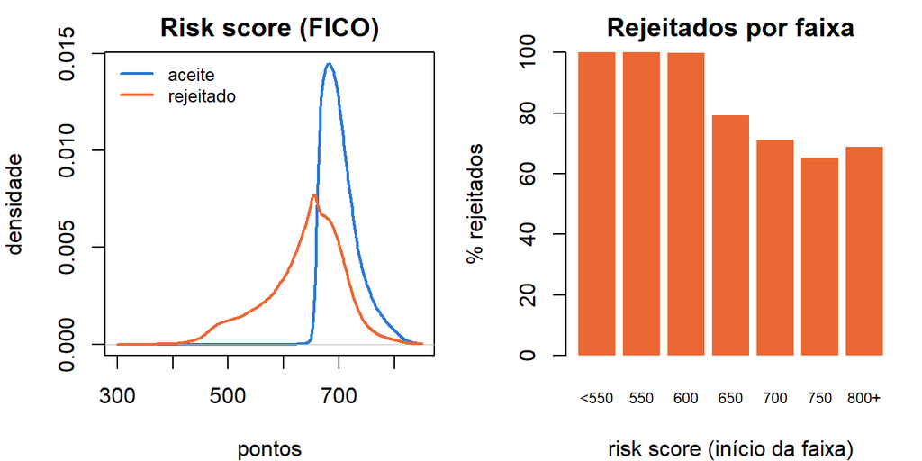

```r
par(mfrow = c(1, 2), mar = c(4, 4, 2, 1))
dens_s <- lapply(split(score$risk_score, score$group), density, from = 300, to = 850, bw = 5)
plot(dens_s$aceite, col = cores_g[["aceite"]], lwd = 2, main = "Risk score (FICO)",
     xlab = "pontos", ylab = "densidade", ylim = range(sapply(dens_s, function(d) d$y)))
lines(dens_s$rejeitado, col = cores_g[["rejeitado"]], lwd = 2)
legend("topleft", names(cores_g), col = cores_g, lwd = 2, bty = "n", cex = 0.8)

# Proporção de rejeitados entre os pedidos de cada faixa de risk score (só descritivo)
faixas <- c(300, 550, 600, 650, 700, 750, 800, 851)
por_faixa <- score[, .(aceites = sum(group == "aceite"), rejeitados = sum(group == "rejeitado")),
                   keyby = .(faixa = cut(risk_score, faixas, right = FALSE, dig.lab = 3))]
por_faixa[, pct_rejeitados := 100 * rejeitados / (aceites + rejeitados)]
barplot(por_faixa$pct_rejeitados, names.arg = c("<550", "550", "600", "650", "700", "750", "800+"),
        col = cores_g[["rejeitado"]], border = NA, main = "Rejeitados por faixa",
        xlab = "risk score (início da faixa)", ylab = "% rejeitados", ylim = c(0, 100),
        cex.names = 0.7)
```

```r
por_faixa[, .(faixa, aceites, rejeitados, pct_rejeitados = round(pct_rejeitados, 1))]
```

```
Key: <faixa>
       faixa aceites rejeitados pct_rejeitados
      <fctr>   <int>      <int>          <num>
1: [300,550)       0     156733          100.0
2: [550,600)       0     157832          100.0
3: [600,650)     230     318331           99.9
4: [650,700)  110300     423371           79.3
5: [700,750)   71044     174110           71.0
6: [750,800)   17021      31998           65.3
7: [800,851)    2287       5061           68.9
```

**Teste e pressupostos.** Mann-Whitney, pelas mesmas razões da hipótese (a): dois grupos independentes (com a ressalva acima) e uma variável ordinal (o *score* é uma pontuação). As formas das distribuições são diferentes, por isso o resultado lê-se como $P(X_{rejeitado} < X_{aceite})$ e não como uma diferença de medianas.

```r
teste_c2 <- wilcox.test(risk_score ~ group, data = score, alternative = "less", exact = FALSE)
teste_c2
```

```
    Wilcoxon rank sum test with continuity correction

data:  risk_score by group
W = 4.9166e+10, p-value < 2.2e-16
alternative hypothesis: true location shift is less than 0
```

```r
s_rejeitado <- score[group == "rejeitado", risk_score]
s_aceite <- score[group == "aceite", risk_score]
rb_c2 <- rank_biserial(s_rejeitado, s_aceite)
ic_c2 <- ic_rank_biserial(s_rejeitado, s_aceite, reps = B_GRANDE)
data.frame(medida = c("rank-biserial (rejeitado vs aceite)", "P(X_rejeitado < X_aceite)"),
           estimativa = round(c(rb_c2, (1 - rb_c2) / 2), 3),
           ic95_inf = round(c(ic_c2[1], (1 - ic_c2[2]) / 2), 3),
           ic95_sup = round(c(ic_c2[2], (1 - ic_c2[1]) / 2), 3))
```

```
                               medida estimativa ic95_inf ic95_sup
1 rank-biserial (rejeitado vs aceite)     -0.614   -0.615   -0.612
2           P(X_rejeitado < X_aceite)      0.807    0.806    0.808
```

```r
resultados$c2 <- data.frame(
  hipotese = "(c2) risk score menor nos rejeitados",
  dados = "aceites e rejeitados (2007-06 a 2013-10, escala FICO)",
  n = sprintf("%d aceites / %d rejeitados", length(s_aceite), length(s_rejeitado)),
  teste = "Mann-Whitney unilateral",
  p = teste_c2$p.value,
  efeito = "rank-biserial",
  estimativa = rb_c2, ic95_inf = ic_c2[1], ic95_sup = ic_c2[2],
  magnitude = as.character(magnitude_rb(rb_c2))
)
```

**Interpretação.**

- **Rejeita-se H0** ($p$ < 2.2e-16): os rejeitados tendem a ter um *risk score* menor.
- **O efeito é grande**: $r_{rb} =$ -0.614 (IC 95% -0.615 a -0.612). Um rejeitado ao acaso tem um *score* menor do que um aceite ao acaso em 80.7% dos casos. As medianas são 650 (rejeitados) e 697 (aceites).
- O gráfico da direita responde diretamente à hipótese do enunciado: a proporção de rejeitados desce à medida que o *score* sobe. Não há nenhum aceite abaixo de 612 pontos, o que indica um limite mínimo na política de crédito. Mesmo nas faixas mais altas, mais de metade dos pedidos é rejeitada: o *score* não é o único critério (DTI, montante, historial).
- **Associação e não causalidade, mesmo aqui.** A LendingClub usa o *score* na decisão, por isso é plausível que parte do efeito seja causal. Mas o teste só mostra a associação: o *score* está também relacionado com outras variáveis usadas na decisão, e os dados não permitem separar o seu efeito próprio.

# 6 Tabela consolidada

**Comparações múltiplas.** Fizeram-se 4 testes. Se cada um usar $\alpha = 0{,}05$, a probabilidade de pelo menos um falso positivo no conjunto é maior do que 5%. A **correção de Holm** controla essa probabilidade: ordenam-se os p-valores do menor para o maior e o $i$-ésimo é comparado com $\alpha / (m - i + 1)$, onde $m = 4$. Dá a mesma garantia que a correção de Bonferroni ($\alpha / m$ para todos), mas rejeita mais vezes quando há efeitos reais. Os p-valores abaixo já vêm ajustados (`p.adjust(..., method = "holm")`).

```r
tabela <- do.call(rbind, unname(resultados))
tabela$p_holm <- p.adjust(tabela$p, method = "holm")
tabela$decisao <- ifelse(tabela$p_holm < ALFA, "rejeita H0", "não rejeita H0")

# p-valores abaixo da precisão da máquina aparecem como "< 2.2e-16"
fmt_p_tabela <- function(p) {
  ifelse(p < .Machine$double.eps, "< 2.2e-16", formatC(p, format = "e", digits = 1))
}
vista <- data.frame(
  "Hipótese" = tabela$hipotese,
  "Dados" = tabela$dados,
  "n" = tabela$n,
  "Teste" = tabela$teste,
  "p (Holm)" = fmt_p_tabela(tabela$p_holm),
  "Efeito [IC 95%]" = sprintf("%s = %.3f [%.3f; %.3f]", tabela$efeito, tabela$estimativa,
                              tabela$ic95_inf, tabela$ic95_sup),
  "Magnitude" = tabela$magnitude,
  "Decisão" = tabela$decisao,
  check.names = FALSE
)
knitr::kable(vista)
```

| Hipótese | Dados | n | Teste | p (Holm) | Efeito [IC 95%] | Magnitude | Decisão |
| --- | --- | --- | --- | --- | --- | --- | --- |
| (a) DTI maior nos Default | treino da classificação (2007-06 a 2011-12) | 3876 Default / 27646 Good | Mann-Whitney unilateral | 2.4e-11 | rank-biserial = 0.065 [0.045; 0.084] | desprezável | rejeita H0 |
| (b) purpose associado ao default | treino da classificação (2007-06 a 2011-12) | 31522 empréstimos, 14 purposes | Qui-quadrado de independência | < 2.2e-16 | V de Cramér = 0.104 [0.093; 0.118] | pequeno | rejeita H0 |
| (c1) montante difere entre aceites e rejeitados | aceites e rejeitados (2007-06 a 2014-12) | 466124 aceites / 3424226 rejeitados | Mann-Whitney bilateral | < 2.2e-16 | rank-biserial = 0.197 [0.195; 0.198] | pequeno | rejeita H0 |
| (c2) risk score menor nos rejeitados | aceites e rejeitados (2007-06 a 2013-10, escala FICO) | 200882 aceites / 1267436 rejeitados | Mann-Whitney unilateral | < 2.2e-16 | rank-biserial = -0.614 [-0.615; -0.612] | grande | rejeita H0 |

```r
# A mesma tabela num ficheiro da documentação (gerado, como as tabelas de exclusões)
destino <- file.path("docs", "02_testes_hipoteses", "tabela_resultados.md")
dir.create(dirname(destino), showWarnings = FALSE)
writeLines(c(
  "# Testes de hipóteses: tabela de resultados",
  "",
  "_Gerado automaticamente por `R/testes_hipoteses.Rmd` - não editar à mão._",
  "",
  sprintf("- Gerado em: %s", Sys.Date()),
  "- Só dados de desenvolvimento; o teste final (2015) não é usado.",
  sprintf("- p-valores com a correção de Holm (%d testes, alfa = %.2f).", nrow(tabela), ALFA),
  sprintf("- IC 95%% por bootstrap (percentis; %d réplicas, %d nos testes com milhões de linhas; semente %d).",
          B, B_GRANDE, SEMENTE),
  "- Magnitude: rank-biserial pelos limiares de Romano et al. (2006); V de Cramér pelos de Cohen (1988).",
  "- Justificação de cada teste, pressupostos e interpretação: `reports/testes_hipoteses.html`.",
  "",
  knitr::kable(vista, format = "pipe")
), destino, useBytes = TRUE)
cat("Gravado:", destino, "\n")
```

```
Gravado: docs/02_testes_hipoteses/tabela_resultados.md
```

# 7 Conclusões

- **As quatro hipóteses rejeitam H0**, mesmo com a correção de Holm. Com amostras deste tamanho isso era de esperar e, sozinho, diz pouco.
- **Os tamanhos dos efeitos são muito diferentes:**
  - o *risk score* separa fortemente aceites e rejeitados (efeito grande);
  - o montante pedido difere pouco entre aceites e rejeitados (efeito pequeno);
  - o `purpose` está associado ao *default* com um efeito global pequeno, mas com categorias de risco muito diferente (*small_business* quase com o triplo de *major_purchase*);
  - o DTI quase não separa os *Default* dos *Good standing* (efeito desprezável), apesar de a taxa de *default* subir de forma monótona com o DTI.
- **Para os modelos da Parte 2:** nenhuma variável isolada separa bem as classes do *default*, por isso é de esperar que os modelos tenham de combinar várias variáveis, e que as não lineares (árvores, *ensembles*) possam ganhar. O `purpose` deve entrar como categoria, com as raras agrupadas.
- **Limitações comuns:**
  - *selection bias*: o *default* só se observa nos aceites, e a política de crédito cortou os casos extremos (DTI de 30% ou mais, *score* abaixo de 612);
  - os dados são observacionais: todas as relações são associações, não causas;
  - não há identificador do mutuário, por isso a independência das observações é aproximada;
  - o montante dos aceites pode ter sido ajustado e a sua data é a de financiamento.

# 8 Figuras para o relatório

Duas figuras resumem os resultados mais visuais: a taxa de *default* por `purpose` (hipótese b) e a percentagem de pedidos rejeitados por faixa de *risk score* (hipótese c2). Usam os números calculados acima e o estilo das figuras da análise exploratória (`src/lending/plot_style.py`: fundo, cores e valores escritos ao lado das barras). São gravadas em `reports/figures/`, ao lado das figuras da análise exploratória.

```r
FIGURAS <- file.path("reports", "figures")
dir.create(FIGURAS, showWarnings = FALSE, recursive = TRUE)

# Cores de src/lending/plot_style.py
SURFACE <- "#fcfcfb"; INK <- "#0b0b0b"; INK2 <- "#52514e"; MUTED <- "#898781"
GRID <- "#e1e0d9"; AXIS <- "#c3c2b7"; AZUL <- "#2a78d6"; LARANJA <- "#eb6834"; CINZA <- "#c3c2b7"

milhares <- function(x) format(x, big.mark = ",", scientific = FALSE, trim = TRUE)

# Barras horizontais com o valor escrito à direita e uma linha vertical para a média global.
# xmax é a largura da área do gráfico (deixa espaço para o texto); eixo é o fim da escala.
barras_h <- function(rotulos, valores, textos, cores, titulo, xlab, xmax, eixo = xmax,
                     ic_inf = NULL, ic_sup = NULL, linha = NULL, linha_txt = NULL,
                     legenda = NULL) {
  par(mar = c(3.2, 9.5, 2.2, 1), bg = SURFACE, family = "sans", fg = AXIS, col.axis = MUTED,
      col.lab = INK2, cex.axis = 0.75, mgp = c(2, 0.5, 0), tcl = -0.25)
  n <- length(valores)
  y <- rev(seq_len(n))                     # o primeiro valor fica em cima
  plot(NA, xlim = c(0, xmax), ylim = c(0.4, n + 0.6), xaxt = "n", yaxt = "n", xaxs = "i",
       bty = "n", xlab = "", ylab = "")
  marcas <- pretty(c(0, eixo))
  marcas <- marcas[marcas <= eixo]
  abline(v = marcas, col = GRID, lwd = 0.6)
  rect(0, y - 0.35, valores, y + 0.35, col = cores, border = NA)
  if (!is.null(ic_inf)) segments(ic_inf, y, ic_sup, y, col = INK2, lwd = 1)
  if (!is.null(linha)) {
    abline(v = linha, col = MUTED, lwd = 1.2)
    text(linha, n + 0.6, linha_txt, pos = 4, col = MUTED, cex = 0.7, xpd = TRUE)
  }
  pos_texto <- if (is.null(ic_sup)) valores else pmax(valores, ic_sup)
  text(pos_texto, y, textos, pos = 4, col = INK2, cex = 0.68, xpd = TRUE)
  axis(1, at = marcas, col = AXIS, col.ticks = AXIS)
  axis(2, at = y, labels = rotulos, las = 1, col = NA, col.ticks = AXIS)
  segments(0, 0.4, 0, n + 0.6, col = AXIS)
  mtext(xlab, side = 1, line = 2, col = INK2, cex = 0.8)
  mtext(titulo, side = 3, line = 0.8, adj = 0, col = INK, cex = 0.95)
  if (!is.null(legenda)) legend("bottomright", legenda$texto, fill = legenda$cor, border = NA,
                                bty = "n", cex = 0.68, text.col = INK2, inset = c(0.01, 0.02))
}

# Desenha no relatório HTML e grava o mesmo gráfico em PNG (tamanho das figuras do projeto)
gravar <- function(ficheiro, desenhar) {
  desenhar()
  png(file.path(FIGURAS, ficheiro), width = 1185, height = 565, res = 150, bg = SURFACE)
  desenhar()
  invisible(dev.off())
}
```

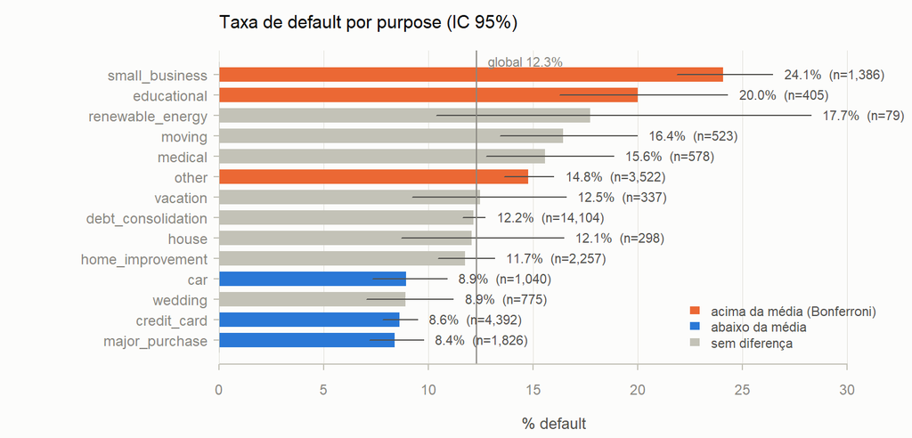

```r
# Hipótese (b): taxa, IC 95% e resíduo de cada purpose (calculados na secção da hipótese b)
fig_b <- merge(por_purpose[, .(purpose, n, taxa, ic95_inf, ic95_sup)],
               residuos[, .(purpose, residuo)], by = "purpose")
setorder(fig_b, -taxa)
fig_b[, cor := ifelse(abs(residuo) > z_critico, ifelse(residuo > 0, LARANJA, AZUL), CINZA)]

gravar("hip_default_por_purpose.png", function() barras_h(
  fig_b$purpose, fig_b$taxa, sprintf("%.1f%%  (n=%s)", fig_b$taxa, milhares(fig_b$n)), fig_b$cor,
  "Taxa de default por purpose (IC 95%)", "% default", xmax = 32,
  ic_inf = fig_b$ic95_inf, ic_sup = fig_b$ic95_sup,
  linha = 100 * taxa_global, linha_txt = sprintf("global %.1f%%", 100 * taxa_global),
  legenda = list(texto = c("acima da média (Bonferroni)", "abaixo da média", "sem diferença"),
                 cor = c(LARANJA, AZUL, CINZA))))
```

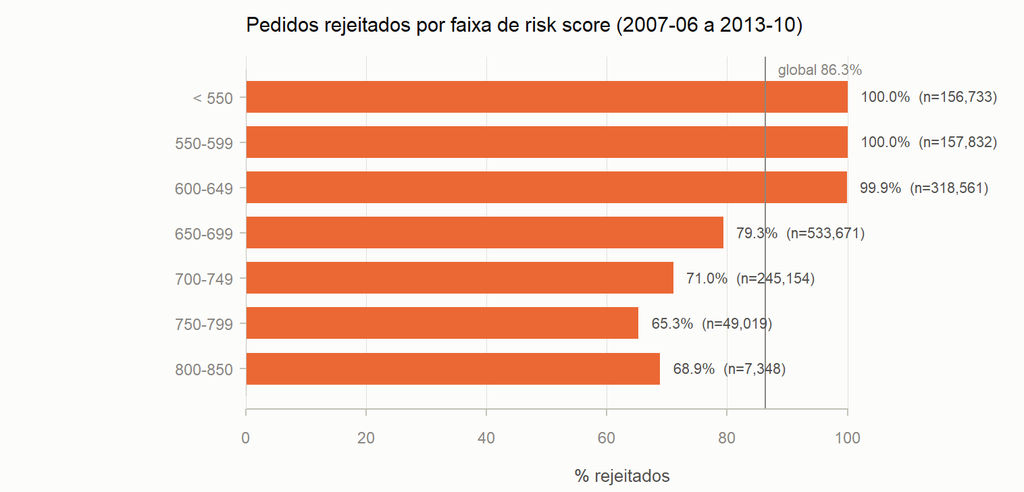

```r
# Hipótese (c2): % de rejeitados por faixa de risk score (calculada na secção da hipótese c2)
rotulos_faixa <- c("< 550", "550-599", "600-649", "650-699", "700-749", "750-799", "800-850")
total_faixa <- por_faixa$aceites + por_faixa$rejeitados
rejeicao_global <- 100 * sum(por_faixa$rejeitados) / sum(total_faixa)

gravar("hip_rejeicao_por_risk_score.png", function() barras_h(
  rotulos_faixa, por_faixa$pct_rejeitados,
  sprintf("%.1f%%  (n=%s)", por_faixa$pct_rejeitados, milhares(total_faixa)), LARANJA,
  "Pedidos rejeitados por faixa de risk score (2007-06 a 2013-10)", "% rejeitados",
  xmax = 125, eixo = 100,
  linha = rejeicao_global, linha_txt = sprintf("global %.1f%%", rejeicao_global)))
```

**Como ler as figuras:**

- **Taxa de *default* por `purpose`:** cada barra tem o intervalo de confiança a 95% e a linha vertical é a taxa global. A cor resulta do teste: laranja e azul são os *purposes* cujo resíduo passa o valor crítico de Bonferroni (acima e abaixo da média); cinzento os que não se distinguem dela. O *renewable_energy* tem uma taxa alta mas fica cinzento, porque com 79 empréstimos o intervalo é largo; o *other* tem uma taxa mais baixa do que o *moving*, mas fica laranja, porque com 3 522 empréstimos o intervalo é estreito.
- **Rejeitados por faixa de *risk score*:** a percentagem de pedidos rejeitados **nos dados** em cada faixa (aceites e rejeitados do período FICO). Não é exatamente a probabilidade de um requerente ser rejeitado, porque os aceites são contados pela data de financiamento e os rejeitados pela do pedido, mas mostra a associação: a rejeição é praticamente total abaixo de 600 pontos e desce até cerca de 65% nas faixas altas.

# 9 Reprodutibilidade

Para gerar este relatório (a partir da pasta do projeto, depois de correr `notebooks/02b_dados_testes_hipoteses.ipynb`):

```
Rscript -e "rmarkdown::render('R/testes_hipoteses.Rmd', output_dir = 'reports')"
```

Precisa dos pacotes `rmarkdown`, `knitr`, `data.table` e `boot`, e do pandoc. Todos os resultados aleatórios usam a semente 42.